# DEM 7283 - Logistic Regression - Other Topics

Corey Sparks, PhD

21 February, 2022

In this example, we continue the discussion of the logistic regression model from [last week](https://github.com/coreysparks/DEM7283/blob/master/code/EX3_logit_probit.html).

This week we examine a few more extensions to the model including model comparison, model nesting and stratification. We also look at using the logistic regression model for a binary classification model, commonly used in machine learning.

### Libraries

```r
#load libraries
library(car, quietly = T)
library(stargazer, quietly = T)
library(survey, quietly = T)
library(questionr, quietly = T)
library(dplyr, quietly = T)
```

```r
library(ggplot2, quietly = T)
```

## Analysis

First make our analytical dataset and our survey design information

```r
library(dplyr)
sub<-brfss20%>%
  select(badhealth,mmsaname, bmi, agec,race_eth, marst, educ,white, black, hispanic, other, smoke, ins, mmsawt, ststr)
#First we tell R our survey design
options(survey.lonely.psu = "adjust")
des<-svydesign(ids=~1, strata=~ststr, weights=~mmsawt, data =sub )
```

## Nested model comparison

Often in a research setting we are interested in comparing several models, and almost never are we satisfied with a single solitary model. This is because the literature on our subjects often has multiple facets to it. So, for instance, we may be interested in how SES mediates the effects of race/ethnicity on health (see [Shuey and Wilson 2008](http://journals.sagepub.com/doi/abs/10.1177/0164027507311151) and [Sudano and Baker 2005](https://www.ncbi.nlm.nih.gov/pubmed/16055252) or [Hummer 1993](http://www.jstor.org/stable/pdf/2579860.pdf) for a few examples of these types of analysis).

$$y = \beta_0 + \text{Race\Eth}$$
$$y = \beta_0 + \text{Race\Eth}
+\text{Gender}$$

$$y = \beta_0 + \text{Race\Eth}
+\text{Gender} + \text{SES}$$
Typically in these types of analysis, predictor variables are entered into the model in “blocks”. For example, let’s look at the self-rated health outcome (0=good or excellent health, 1= fair/poor health) from [last week](http://rpubs.com/corey_sparks/245830). But instead of entering all variables in the model simultaneously, we begin with the effect of race/ethnicity, then add the effect of SES then the effects of health behavior variables.

```r
fit.logit1<-svyglm(badhealth~race_eth,design= des, family=binomial) #race only
fit.logit2<-svyglm(badhealth~race_eth+educ,design= des, family=binomial) #race+education
fit.logit3<-svyglm(badhealth~race_eth+educ+ins+smoke,design= des, family=binomial)#race+education+health behaviors
```

In model 1 we see that Hispanics and blacks have a higher odds of reporting poor self rated health, compared to non-Hispanic whites, while the “other” group shows lower odds of reporting poor health.

Now, let’s see if, by controlling for education, some of these differences go away, or are reduced. The fancy word for when an effect is reduced is *“attenuated”*. We will also do a test to see if the model with the education term significantly improves the model fit. Traditionally this would be done using a likelihood ratio test, but in survey models, that’s not kosher

```r
summary(fit.logit2)
```

```
##
## Call:
## svyglm(formula = badhealth ~ race_eth + educ, design = des, family = binomial)
##
## Survey design:
## svydesign(ids = ~1, strata = ~ststr, weights = ~mmsawt, data = sub)
##
## Coefficients:
##                      Estimate Std. Error t value Pr(>|t|)
## (Intercept)          -0.60051    0.08358  -7.185 6.75e-13 ***
## race_ethnh_black      0.18599    0.05783   3.216 0.001299 **
## race_ethnh_multirace  0.10781    0.09856   1.094 0.273989
## race_ethnh_other     -0.37908    0.08892  -4.263 2.02e-05 ***
## race_ethnhwhite      -0.10121    0.04754  -2.129 0.033277 *
## educ1somehs          -0.35159    0.09654  -3.642 0.000271 ***
## educ2hsgrad          -1.03341    0.08785 -11.763  < 2e-16 ***
## educ3somecol         -1.28642    0.08808 -14.604  < 2e-16 ***
## educ4colgrad         -2.04605    0.08831 -23.169  < 2e-16 ***
## ---
## Signif. codes:  0 '***' 0.001 '**' 0.01 '*' 0.05 '.' 0.1 ' ' 1
##
## (Dispersion parameter for binomial family taken to be 0.9981514)
##
## Number of Fisher Scoring iterations: 5
```

```r
regTermTest(fit.logit2,
            test.terms = ~educ,
            method="Wald",
            df = NULL)
```

```
## Wald test for educ
##  in svyglm(formula = badhealth ~ race_eth + educ, design = des, family = binomial)
## F =  338.8501  on  4  and  188370  df: p= < 2.22e-16
```

The F test also suggest that the second model fits the data better than the first. It is another of these omnibus tests that asks whether there is any variation in our outcome by education in the second model.

Next we consider the third model, which contains health behaviors of current smoking and insurance coverage:

```r
summary(fit.logit3)
```

```
##
## Call:
## svyglm(formula = badhealth ~ race_eth + educ + ins + smoke, design = des,
##     family = binomial)
##
## Survey design:
## svydesign(ids = ~1, strata = ~ststr, weights = ~mmsawt, data = sub)
##
## Coefficients:
##                      Estimate Std. Error t value Pr(>|t|)
## (Intercept)          -0.89780    0.09438  -9.512  < 2e-16 ***
## race_ethnh_black      0.07525    0.06015   1.251    0.211
## race_ethnh_multirace -0.04630    0.10228  -0.453    0.651
## race_ethnh_other     -0.42641    0.08612  -4.951 7.38e-07 ***
## race_ethnhwhite      -0.30652    0.04931  -6.216 5.10e-10 ***
## educ1somehs          -0.45706    0.10169  -4.495 6.98e-06 ***
## educ2hsgrad          -1.09177    0.09158 -11.921  < 2e-16 ***
## educ3somecol         -1.32904    0.09246 -14.374  < 2e-16 ***
## educ4colgrad         -2.00765    0.09276 -21.643  < 2e-16 ***
## ins                   0.25810    0.05932   4.351 1.36e-05 ***
## smokeCurrent          0.70869    0.04367  16.227  < 2e-16 ***
## smokeFormer           0.50995    0.03772  13.518  < 2e-16 ***
## ---
## Signif. codes:  0 '***' 0.001 '**' 0.01 '*' 0.05 '.' 0.1 ' ' 1
##
## (Dispersion parameter for binomial family taken to be 0.9811364)
##
## Number of Fisher Scoring iterations: 5
```

```r
regTermTest(fit.logit3,
            test.terms=~ins+smoke,
            method="Wald",
            df = NULL)
```

```
## Wald test for ins smoke
##  in svyglm(formula = badhealth ~ race_eth + educ + ins + smoke, design = des,
##     family = binomial)
## F =  114.8911  on  3  and  177376  df: p= < 2.22e-16
```

```r
library(gtsummary)
f1<- fit.logit1%>%
  tbl_regression(exponentiate =T)

f2<- fit.logit2%>%
  tbl_regression(exponentiate =T)

f3<- fit.logit3%>%
  tbl_regression(exponentiate =T)



f_all <- tbl_merge(tbls =list(f1, f2, f3),
                    tab_spanner = c("**Model 1**", "**Model 2**", "**Model 3**"))

f_all
```

| **Characteristic** | **Model 1** **OR**<sup>1</sup> | **Model 1** **95% CI**<sup>1</sup> | **Model 1** **p-value** | **Model 2** **OR**<sup>1</sup> | **Model 2** **95% CI**<sup>1</sup> | **Model 2** **p-value** | **Model 3** **OR**<sup>1</sup> | **Model 3** **95% CI**<sup>1</sup> | **Model 3** **p-value** |
| --- | --- | --- | --- | --- | --- | --- | --- | --- | --- |
| race_eth |  |  |  |  |  |  |  |  |  |
| hispanic | — | — |  | — | — |  | — | — |  |
| nh_black | 0.86 | 0.77, 0.96 | 0.005 | 1.20 | 1.08, 1.35 | 0.001 | 1.08 | 0.96, 1.21 | 0.2 |
| nh_multirace | 0.77 | 0.64, 0.93 | 0.006 | 1.11 | 0.92, 1.35 | 0.3 | 0.95 | 0.78, 1.17 | 0.7 |
| nh_other | 0.40 | 0.34, 0.47 | <0.001 | 0.68 | 0.58, 0.81 | <0.001 | 0.65 | 0.55, 0.77 | <0.001 |
| nhwhite | 0.56 | 0.51, 0.61 | <0.001 | 0.90 | 0.82, 0.99 | 0.033 | 0.74 | 0.67, 0.81 | <0.001 |
| educ |  |  |  |  |  |  |  |  |  |
| 0Prim |  |  |  | — | — |  | — | — |  |
| 1somehs |  |  |  | 0.70 | 0.58, 0.85 | <0.001 | 0.63 | 0.52, 0.77 | <0.001 |
| 2hsgrad |  |  |  | 0.36 | 0.30, 0.42 | <0.001 | 0.34 | 0.28, 0.40 | <0.001 |
| 3somecol |  |  |  | 0.28 | 0.23, 0.33 | <0.001 | 0.26 | 0.22, 0.32 | <0.001 |
| 4colgrad |  |  |  | 0.13 | 0.11, 0.15 | <0.001 | 0.13 | 0.11, 0.16 | <0.001 |
| HAVE ANY HEALTH CARE COVERAGE |  |  |  |  |  |  | 1.29 | 1.15, 1.45 | <0.001 |
| smoke |  |  |  |  |  |  |  |  |  |
| NeverSmoked |  |  |  |  |  |  | — | — |  |
| Current |  |  |  |  |  |  | 2.03 | 1.86, 2.21 | <0.001 |
| Former |  |  |  |  |  |  | 1.67 | 1.55, 1.79 | <0.001 |

<sup>*1*</sup> OR = Odds Ratio, CI = Confidence Interval

### Comparing models

There are several ways to compare models to one another, and when using nested models, this is a common thing to do. Mainly, you want to see if, by including more predictors in the model, are you explaining more variation in the outcome. One way of doing this is the Akaike Information Criteria (AIC) for the models. The AIC consists of two components, one showing overall model deviance, or residual variance and a penalty term for the number of parameters in a model. A general form of it is:

$$AIC = -2LL(\theta) + 2k$$
TYpically, the lower the value, the better fitting the model. **NOTE** you can only compare models fit to the same dataset using AIC

```r
AIC(fit.logit1, fit.logit2, fit.logit3)
```

```
##         eff.p      AIC deltabar
## [1,] 20.66553 147656.1 5.166383
## [2,] 46.28629 140381.7 5.785786
## [3,] 60.76909 128640.0 5.524463
```

We see here that the third model has an AIC of *128640.0*, which is much lower than the other two models. In practice, if two models are less than 10 AIC points different from one another, you are inclined to go with the **more parsimonious model.**

#### Comparing models using Likelihood ratio test

We can construct a test that two models are fitting the data the same using a **Likelihood ratio test**

```r
anova(fit.logit1, fit.logit2)
```

```
## Working (Rao-Scott+F) LRT for educ
##  in svyglm(formula = badhealth ~ race_eth + educ, design = des, family = binomial)
## Working 2logLR =  1165.779 p= < 2.22e-16
## (scale factors:  1.8 1 0.7 0.5 );  denominator df= 188370
```

Here the likelihood ratio test `2logLR` shows a significant difference in the between models `fit.logit1` and `fit.logit2`, suggesting that `fit.logit2` better explains the data than `fit.logit1` does.

The `anova` method is very useful for comparing alternative models and can be used on most of the models fit by `svyglm()`, `glm()` and `lm()`.

```r
anova(fit.logit2, fit.logit3)
```

```
## Working (Rao-Scott+F) LRT for ins smoke
##  in svyglm(formula = badhealth ~ race_eth + educ + ins + smoke, design = des,
##     family = binomial)
## Working 2logLR =  2111.31 p= < 2.22e-16
## (scale factors:  1.3 0.9 0.79 );  denominator df= 177376
```

## Stratified models

Often in the literature, we will see models stratified by some predictor. This is usually because a specific hypothesis is stated regarding how the effect of a particular predictor varies by some categorical variable. In this case, we may be interested in considering if education or smoking universally affects the poor health outcome. We get at this by *stratifying* our analysis by race (in this example).

The easiest way to do this is to subset the data by race and run the models separately.

**The first thing we do** is test for the interaction of education and race. If this interaction is not significant, we have no justification for proceeding, because the effect of education does not vary by race group. **This is the test of parallel slopes, a’ la the ANCOVA model**

```r
fit.logitint<-svyglm(badhealth~race_eth*educ+ins+smoke,
                     design= des,
                     family=binomial)#race*education interaction+health behaviors
regTermTest(fit.logitint,
            test.terms = ~race_eth:educ,
            method = "Wald", df=NULL)
```

```
## Wald test for race_eth:educ
##  in svyglm(formula = badhealth ~ race_eth * educ + ins + smoke, design = des,
##     family = binomial)
## F =  1.200885  on  16  and  177360  df: p= 0.25773
```

```r
fit.unrestricted<-svyglm(badhealth~educ+ins+smoke,
                         design= des,
                         family=binomial)
fit.logit.white<-svyglm(badhealth~(educ+ins+smoke),
                        design= subset(des, white==1),
                        family=binomial)
fit.logit.black<-svyglm(badhealth~(educ+ins+smoke),
                        design= subset(des, black==1),
                        family=binomial)
fit.logit.hisp<-svyglm(badhealth~(educ+ins+smoke),
                       design= subset(des, hispanic==1),
                       family=binomial)
```

Here we examine the model results next to one another

```r
library(gtsummary)
f1<- fit.logit.hisp%>%
  tbl_regression(exponentiate =T)

f2<- fit.logit.black%>%
  tbl_regression(exponentiate =T)

f3<- fit.logit.white%>%
  tbl_regression(exponentiate =T)



f_all <- tbl_merge(tbls =list(f1, f2, f3),
                    tab_spanner = c("**Hispanic Model**", "**Black Model**", "**White Model**"))

f_all
```

| **Characteristic** | **Hispanic Model** **OR**<sup>1</sup> | **Hispanic Model** **95% CI**<sup>1</sup> | **Hispanic Model** **p-value** | **Black Model** **OR**<sup>1</sup> | **Black Model** **95% CI**<sup>1</sup> | **Black Model** **p-value** | **White Model** **OR**<sup>1</sup> | **White Model** **95% CI**<sup>1</sup> | **White Model** **p-value** |
| --- | --- | --- | --- | --- | --- | --- | --- | --- | --- |
| educ |  |  |  |  |  |  |  |  |  |
| 0Prim | — | — |  | — | — |  | — | — |  |
| 1somehs | 0.54 | 0.40, 0.72 | <0.001 | 0.74 | 0.44, 1.22 | 0.2 | 0.86 | 0.63, 1.16 | 0.3 |
| 2hsgrad | 0.34 | 0.26, 0.44 | <0.001 | 0.37 | 0.23, 0.59 | <0.001 | 0.42 | 0.32, 0.56 | <0.001 |
| 3somecol | 0.24 | 0.18, 0.32 | <0.001 | 0.27 | 0.17, 0.43 | <0.001 | 0.36 | 0.27, 0.47 | <0.001 |
| 4colgrad | 0.15 | 0.11, 0.19 | <0.001 | 0.14 | 0.09, 0.23 | <0.001 | 0.18 | 0.14, 0.24 | <0.001 |
| ins | 1.37 | 1.11, 1.68 | 0.003 | 1.27 | 0.98, 1.64 | 0.066 | 1.26 | 1.10, 1.45 | <0.001 |
| smoke |  |  |  |  |  |  |  |  |  |
| NeverSmoked | — | — |  | — | — |  | — | — |  |
| Current | 1.31 | 1.02, 1.70 | 0.038 | 1.86 | 1.50, 2.32 | <0.001 | 2.43 | 2.22, 2.66 | <0.001 |
| Former | 1.42 | 1.14, 1.78 | 0.002 | 1.79 | 1.48, 2.17 | <0.001 | 1.78 | 1.65, 1.93 | <0.001 |

<sup>*1*</sup> OR = Odds Ratio, CI = Confidence Interval

```r
beta.test<-function(model1, model2, betaname){
s1<-summary(model1)$coef
s2<-summary(model2)$coef
db <- ((s2[rownames(s2)==betaname,1]-s1[rownames(s1)==betaname,1]))^2
sd <-s2[rownames(s2)==betaname,2]^2+s1[rownames(s1)==betaname,2]^2
td <- db/sd
beta1=s1[rownames(s1)==betaname,1]
beta2=s2[rownames(s2)==betaname,1]
pv<-1- pchisq(td, df = 1)
print(list(beta=betaname,beta1=beta1, beta2=beta2, x2=td, pvalue=pv))
}
```

Test for $\beta_{1j} = \beta_{1k}$ in two models $j \text{ and } k$
$$z= \frac{\beta_{1j} - \beta_{1k}}{\left[
s.e.(\beta_{1j}) \right]^2+\left[ s.e.(\beta_{1k})
\right]^2}$$

```r
 beta.test(fit.logit.hisp, fit.logit.white, betaname = "educ4colgrad")
```

```
## $beta
## [1] "educ4colgrad"
##
## $beta1
## [1] -1.929904
##
## $beta2
## [1] -1.709262
##
## $x2
## [1] 1.182137
##
## $pvalue
## [1] 0.2769214
```

Which in this case, shows that the effect of college education is not significantly different between Hispanic and Non Hispanic white respondents.

## Logistic Regression as a Predictive Model

## Classification methods and models

In classification methods, we are typically interested in using some observed characteristics of a case to predict a binary categorical outcome. This can be extended to a multi-category outcome, but the largest number of applications involve a 1/0 outcome.

Below, we look at using Logistic regression

There are other methods for doing this that we will not examine but these are probably the easiest to understand.

In these examples, we will use the Demographic and Health Survey [Model Data](https://dhsprogram.com/data/Model-Datasets.cfm). These are based on the DHS survey, but are publicly available and are used to practice using the DHS data sets, but don’t represent a real country.

In this example, we will use the outcome of contraceptive choice (modern vs other/none) as our outcome.

```r
library(haven)
dat<-url("https://github.com/coreysparks/data/blob/master/ZZIR62FL.DTA?raw=true")
model.dat<-read_dta(dat)
model.dat<-zap_labels(model.dat)
```

Here we recode some of our variables and limit our data to those women who are not currently pregnant and who are sexually active.

```r
library(dplyr)

model.dat2<-model.dat%>%
  mutate(region = v024,
         modcontra= as.factor(ifelse(v364 ==1,1, 0)),
         age = v012,
         livchildren=v218,
         educ = v106,
         currpreg=v213,
         knowmodern=ifelse(v301==3, 1, 0),
         age2=v012^2)%>%
  filter(currpreg==0, v536>0)%>% #notpreg, sex active
  dplyr::select(caseid, region, modcontra,age, age2,livchildren, educ, knowmodern)
```

```r
knitr::kable(head(model.dat2))
```

| caseid | region | modcontra | age | age2 | livchildren | educ | knowmodern |
| --- | --- | --- | --- | --- | --- | --- | --- |
| 1 1 2 | 2 | 0 | 30 | 900 | 4 | 0 | 1 |
| 1 4 2 | 2 | 0 | 42 | 1764 | 2 | 0 | 1 |
| 1 4 3 | 2 | 0 | 25 | 625 | 3 | 1 | 1 |
| 1 5 1 | 2 | 0 | 25 | 625 | 2 | 2 | 1 |
| 1 6 2 | 2 | 0 | 37 | 1369 | 2 | 0 | 1 |
| 1 6 3 | 2 | 0 | 17 | 289 | 0 | 2 | 0 |

### using caret to create training and test sets.

In predictive models, we split the data into two sets, a training set and a test set. The training set will be used to estimate the model parameters, and the test set will be used to validate the model’s predictive ability.

We use an 80% training fraction, which is standard.

```r
library(caret)
set.seed(1115)
train<- createDataPartition(y = model.dat2$modcontra,
                            p = .80,
                            list=F)

model.dat2train<-model.dat2[train,]
model.dat2test<-model.dat2[-train,]

table(model.dat2train$modcontra)
```

```
##
##    0    1
## 4036 1409
```

```r
prop.table(table(model.dat2train$modcontra))
```

```
##
##         0         1
## 0.7412305 0.2587695
```

```r
summary(model.dat2train)
```

```
##     caseid              region      modcontra      age             age2
##  Length:5445        Min.   :1.000   0:4036    Min.   :15.00   Min.   : 225.0
##  Class :character   1st Qu.:1.000   1:1409    1st Qu.:21.00   1st Qu.: 441.0
##  Mode  :character   Median :2.000             Median :29.00   Median : 841.0
##                     Mean   :2.164             Mean   :29.78   Mean   : 976.8
##                     3rd Qu.:3.000             3rd Qu.:37.00   3rd Qu.:1369.0
##                     Max.   :4.000             Max.   :49.00   Max.   :2401.0
##   livchildren          educ          knowmodern
##  Min.   : 0.000   Min.   :0.0000   Min.   :0.0000
##  1st Qu.: 1.000   1st Qu.:0.0000   1st Qu.:1.0000
##  Median : 2.000   Median :0.0000   Median :1.0000
##  Mean   : 2.546   Mean   :0.7381   Mean   :0.9442
##  3rd Qu.: 4.000   3rd Qu.:2.0000   3rd Qu.:1.0000
##  Max.   :10.000   Max.   :3.0000   Max.   :1.0000
```

## Logistic regression for classification

Here we use a basic binomial GLM to estimate the probability of a woman using modern contraception. We use information on their region of residence, age, number of living children and level of education.

This model can be written:
$$ln \left (
\frac{Pr(\text{Modern Contraception})}{1-Pr(\text{Modern
Contraception})} \right ) = X' \beta$$

Which can be converted to the probability scale via the inverse logit transform:

$$Pr(\text{Modern Contraception}) =
\frac{1}{1+exp (-X' \beta)}$$

```r
glm1<-glm(modcontra~factor(region)+scale(age)+scale(age2)+scale(livchildren)+factor(educ),
          data=model.dat2train[,-1],
          family = binomial)
summary(glm1)
```

```
##
## Call:
## glm(formula = modcontra ~ factor(region) + scale(age) + scale(age2) +
##     scale(livchildren) + factor(educ), family = binomial, data = model.dat2train[,
##     -1])
##
## Deviance Residuals:
##     Min       1Q   Median       3Q      Max
## -1.4073  -0.7103  -0.5734   1.0669   2.3413
##
## Coefficients:
##                    Estimate Std. Error z value Pr(>|z|)
## (Intercept)        -1.91240    0.06807 -28.095  < 2e-16 ***
## factor(region)2     0.38755    0.08534   4.541 5.60e-06 ***
## factor(region)3     0.62565    0.09531   6.564 5.23e-11 ***
## factor(region)4     0.30066    0.09454   3.180 0.001471 **
## scale(age)          0.63678    0.26540   2.399 0.016425 *
## scale(age2)        -0.98328    0.26194  -3.754 0.000174 ***
## scale(livchildren)  0.17004    0.05408   3.144 0.001665 **
## factor(educ)1       0.43835    0.10580   4.143 3.43e-05 ***
## factor(educ)2       1.38923    0.08646  16.068  < 2e-16 ***
## factor(educ)3       1.54061    0.16086   9.577  < 2e-16 ***
## ---
## Signif. codes:  0 '***' 0.001 '**' 0.01 '*' 0.05 '.' 0.1 ' ' 1
##
## (Dispersion parameter for binomial family taken to be 1)
##
##     Null deviance: 6226.5  on 5444  degrees of freedom
## Residual deviance: 5629.0  on 5435  degrees of freedom
## AIC: 5649
##
## Number of Fisher Scoring iterations: 4
```

We see that all the predictors are significantly related to our outcome

Next we see how the model performs in terms of accuracy of prediction. This is new comparison to how we typically use logistic regression.

We use the `predict()` function to get the estimated class probabilities for each case

```r
tr_pred<- predict(glm1,
                  newdata = model.dat2train,
                  type = "response")

head(tr_pred)
```

```
##          1          2          3          4          5          6
## 0.22002790 0.31137928 0.15091505 0.20389088 0.08726724 0.18808481
```

These are the estimated probability that each of these women used modern contraception, based on the model.

In order to create classes (uses modern vs doesn’t use modern contraception) we have to use a **decision rule**. A decision rule is when we choose a cut off point, or *threshold* value of the probability to classify each observation as belonging to one class or the other.

A basic decision rule is if $Pr(y=\text{Modern Contraception} |X) >.5$ Then classify the observation as a modern contraception user, and otherwise not. This is what we will use here.

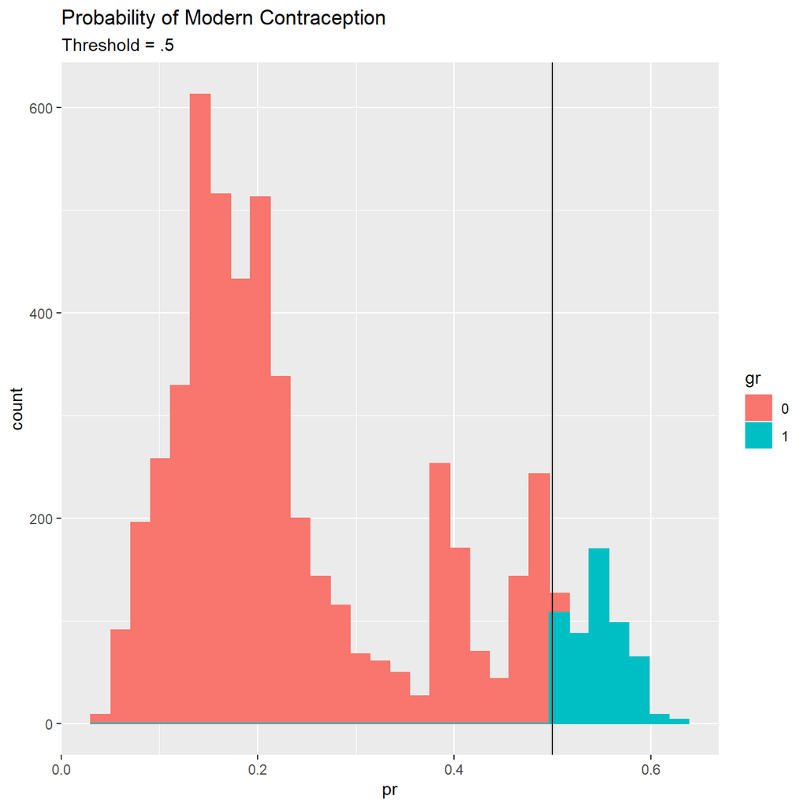

```r
tr_predcl<-factor(ifelse(tr_pred>.5, 1, 0))

library(ggplot2)

pred1<-data.frame(pr=tr_pred,
                  gr=tr_predcl,
                  modcon=model.dat2train$modcontra)

pred1%>%
  ggplot()+
  geom_histogram(aes(x=pr, color=gr, fill=gr))+
  ggtitle(label = "Probability of Modern Contraception",
          subtitle = "Threshold = .5")+
  geom_vline(xintercept=.5)
```

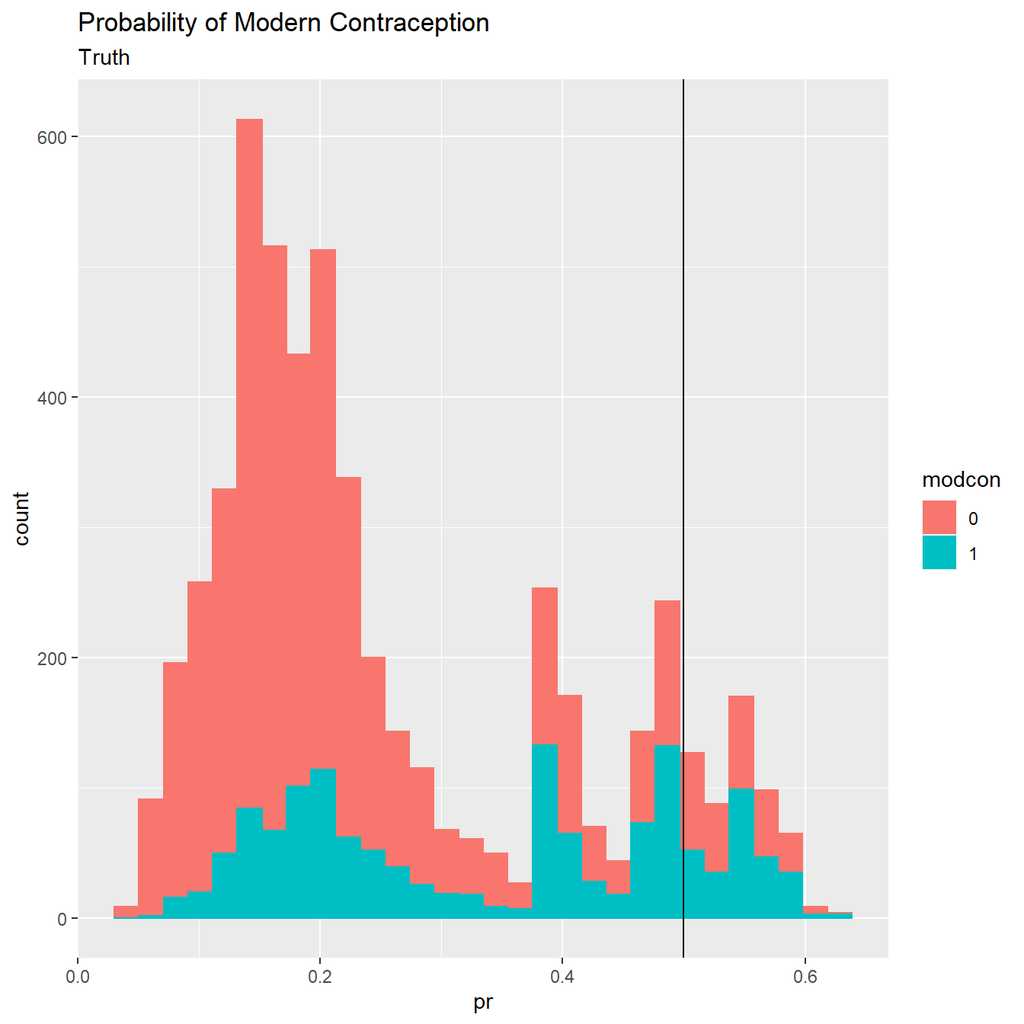

```r
pred1%>%
  ggplot()+
  geom_histogram(aes(x=pr, color=modcon, fill=modcon))+
  ggtitle(label = "Probability of Modern Contraception",
          subtitle = "Truth")+
  geom_vline(xintercept=.5)
```

Next we need to see how we did. A simple cross tab of the observed classes versus the predicted classes is called the **confusion matrix**.

```r
table( tr_predcl,
       model.dat2train$modcontra)
```

```
##
## tr_predcl    0    1
##         0 3761 1142
##         1  275  267
```

This is great, but typically it’s easier to understand the model’s predictive ability by converting these to proportions. The `confusionMatrix()` function in `caret` can do this, plus other stuff.

This provides lots of output summarizing the classification results. At its core is the matrix of observed classes versus predicted classes. I got one depiction of this [here](https://www.geeksforgeeks.org/confusion-matrix-machine-learning/) and from the [Wikipedia page](https://en.wikipedia.org/wiki/Confusion_matrix)

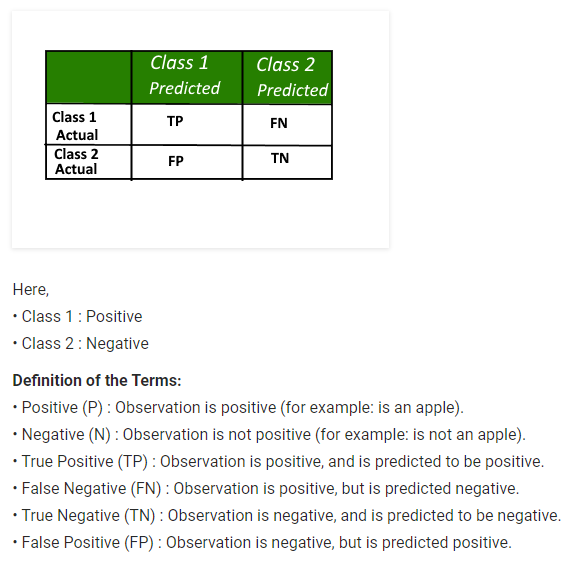

Confusion matrix

Lots of information on the predictive accuracy can be found from this 2x2 table:

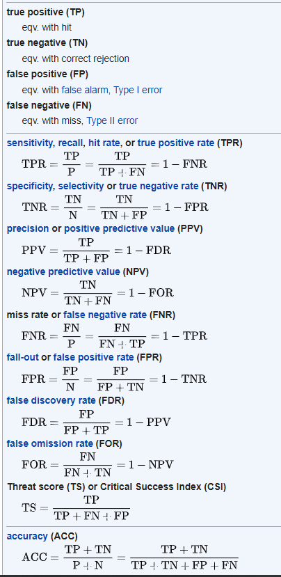

Confusion matrix

Generally, we are interested in overall accuracy, sensitivity and specificity.

```r
cm1<-confusionMatrix(data = tr_predcl,
                     reference = model.dat2train$modcontra )
cm1
```

```
## Confusion Matrix and Statistics
##
##           Reference
## Prediction    0    1
##          0 3761 1142
##          1  275  267
##
##                Accuracy : 0.7398
##                  95% CI : (0.7279, 0.7514)
##     No Information Rate : 0.7412
##     P-Value [Acc > NIR] : 0.6046
##
##                   Kappa : 0.1517
##
##  Mcnemar's Test P-Value : <2e-16
##
##             Sensitivity : 0.9319
##             Specificity : 0.1895
##          Pos Pred Value : 0.7671
##          Neg Pred Value : 0.4926
##              Prevalence : 0.7412
##          Detection Rate : 0.6907
##    Detection Prevalence : 0.9005
##       Balanced Accuracy : 0.5607
##
##        'Positive' Class : 0
##
```

Overall the model has a 73.976% accuracy, which isn’t bad! What is bad is some of the other measures. The sensitivity 93%, and the Specificity is 19 In other word the model is pretty good at predicting if you don’t use modern contraception, but not at predicting if you do.

We could try a different decision rule, in this case, I use the mean of the response as the cutoff value.

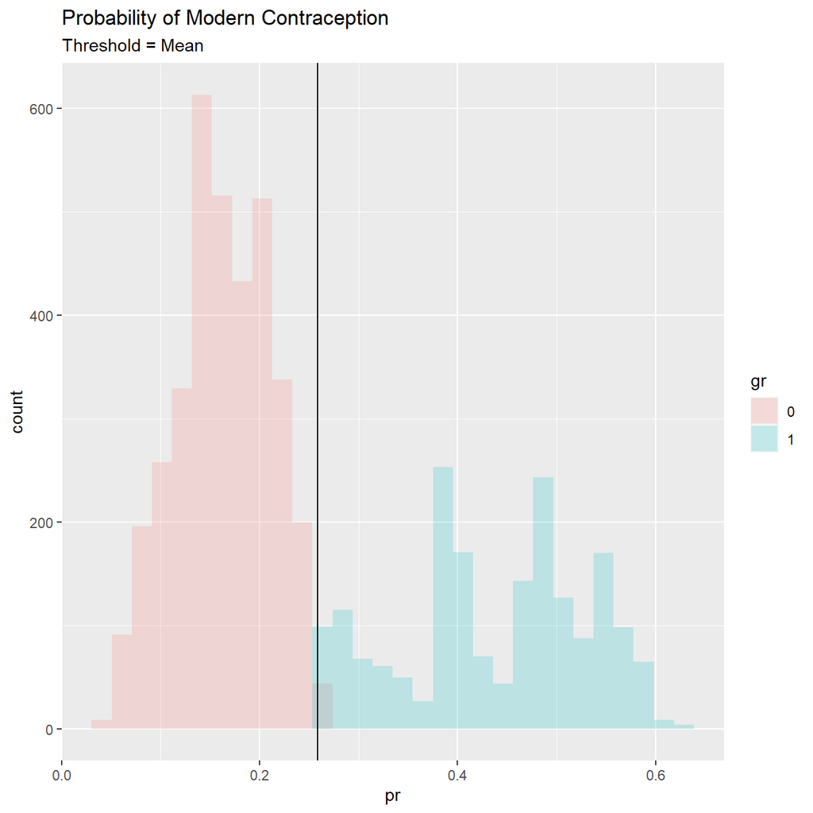

```r
tr_predcl<-factor(ifelse(tr_pred>mean(I(model.dat2train$modcontra==1)), 1, 0)) #mean of response

pred2<-data.frame(pr=tr_pred,
                  gr=tr_predcl,
                  modcon=model.dat2train$modcontra)

pred2%>%
  ggplot(aes(x=pr, fill=gr))+
  geom_histogram(position="identity",
                 alpha=.2)+
  ggtitle(label = "Probability of Modern Contraception",
          subtitle = "Threshold = Mean")+
  geom_vline(xintercept=mean(I(model.dat2train$modcontra==1)))
```

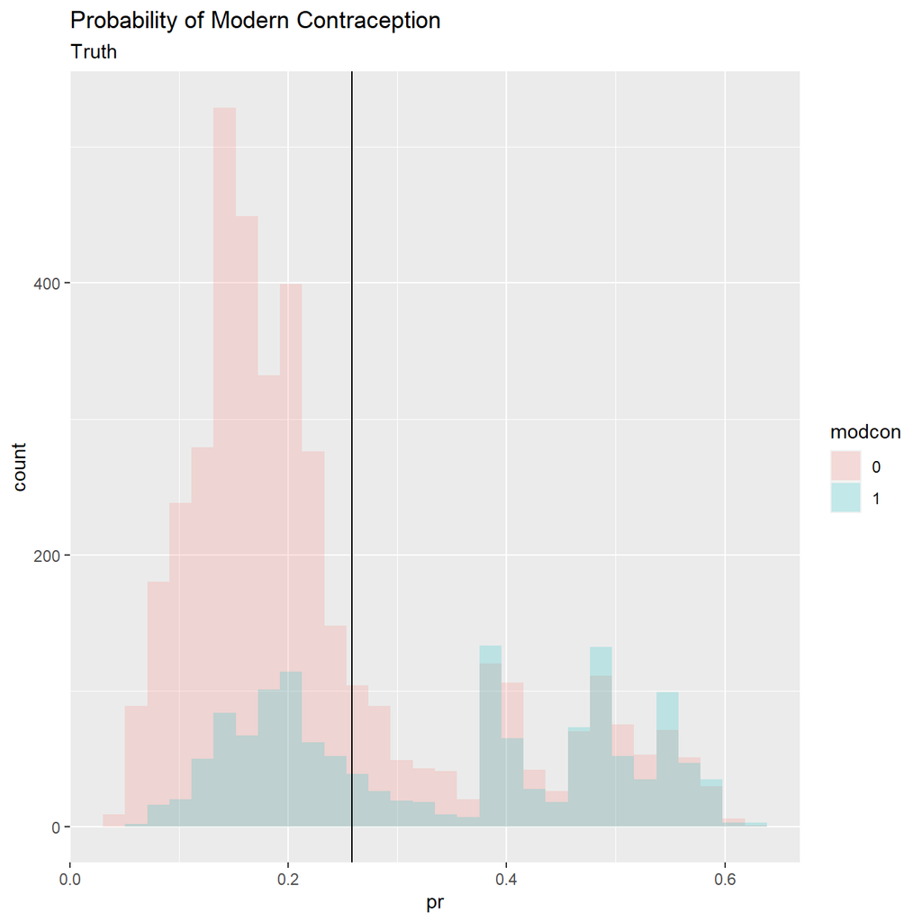

```r
pred2%>%
  ggplot(aes(x=pr, fill=modcon))+
  geom_histogram(position="identity",
                 alpha=.2)+
  ggtitle(label = "Probability of Modern Contraception",
          subtitle = "Truth")+
  geom_vline(xintercept=mean(I(model.dat2train$modcontra==1)))
```

```r
confusionMatrix(data = tr_predcl,
                model.dat2train$modcontra,
                positive = "1" )
```

```
## Confusion Matrix and Statistics
##
##           Reference
## Prediction    0    1
##          0 2959  581
##          1 1077  828
##
##                Accuracy : 0.6955
##                  95% CI : (0.6831, 0.7077)
##     No Information Rate : 0.7412
##     P-Value [Acc > NIR] : 1
##
##                   Kappa : 0.2878
##
##  Mcnemar's Test P-Value : <2e-16
##
##             Sensitivity : 0.5877
##             Specificity : 0.7332
##          Pos Pred Value : 0.4346
##          Neg Pred Value : 0.8359
##              Prevalence : 0.2588
##          Detection Rate : 0.1521
##    Detection Prevalence : 0.3499
##       Balanced Accuracy : 0.6604
##
##        'Positive' Class : 1
##
```

Next we do this on the test set to evaluate model performance outside of the training data

```r
pred_test<-predict(glm1,
                   newdata=model.dat2test,
                   type="response")

pred_cl<-factor(ifelse(pred_test > mean( I(model.dat2test$modcontra==1)), 1, 0))

table(model.dat2test$modcontra,pred_cl)
```

```
##    pred_cl
##       0   1
##   0 720 288
##   1 154 198
```

```r
confusionMatrix(data = pred_cl,model.dat2test$modcontra )
```

```
## Confusion Matrix and Statistics
##
##           Reference
## Prediction   0   1
##          0 720 154
##          1 288 198
##
##                Accuracy : 0.675
##                  95% CI : (0.6494, 0.6999)
##     No Information Rate : 0.7412
##     P-Value [Acc > NIR] : 1
##
##                   Kappa : 0.2463
##
##  Mcnemar's Test P-Value : 2.513e-10
##
##             Sensitivity : 0.7143
##             Specificity : 0.5625
##          Pos Pred Value : 0.8238
##          Neg Pred Value : 0.4074
##              Prevalence : 0.7412
##          Detection Rate : 0.5294
##    Detection Prevalence : 0.6426
##       Balanced Accuracy : 0.6384
##
##        'Positive' Class : 0
##
```

In the test data, the model does about as well as it did on the training data, which is ideal.